# Loops and Functions workshop

Mauro

November 30, 2017

The idea of this workshop is to help make your code more clean and enficient by reducing code duplication. This has three main benefits:

1. It’s easier to see the intent of your code, because your eyes are drawn to what’s different, not what stays the same.
2. It’s easier to respond to changes in requirements. As your needs change, you only need to make changes in one place, rather than remembering to change every place that you copied-and-pasted the code.
3. You’re likely to have fewer bugs because each line of code is used in more places.

# Loops in R

“Looping”, “cycling”, “iterating” or just replicating instructions is an old practice that originated well before the invention of computers. It is nothing more than automating a multi-step process by organizing sequences of actions and grouping the parts that need to be repeated.

The main ideia is to look for regularities in your code. As a general rules-of-thumb: if you repeat the same line of code 3 or more times (just changing a few parameters) then you should use a loop!

For example, let’s estimate the mean for all the columns of a given data frame:

```r
# generates a dataset with 4 columns and 10 rows
# with numbers drawn from a normal distribution
set.seed(666) # for consistency
my_df = data.frame(a = rnorm(10), b = rnorm(10),
                   c = rnorm(10), d = rnorm(10))

# mean of the column a
mean(my_df$a)
# mean of the column b
mean(my_df$b)
# mean of the column c
mean(my_df$c)
# mean of the column d
mean(my_df$a)
```

Can you find the repetitive pattern in this example? Did you notice the error in the code? This kind of error is pretty common when copying and pasting…

There are basically 3 kinds of loops:

- `for( variable in sequence ){ body }`; useful when one knows exactly how many times (ie, `sequence`) to run a chunk of code (ie, `body`).
- `while( condition ){ body }`; useful when one needs to run a chunk of code (ie, `body`) for as long as the `condition` is `TRUE`. (Really useful to run simulations that must meet a certain criteria!)
- `repeat{ body }`; similar to `while` (see below for details).

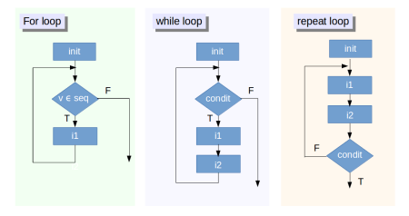

**NOTE:** Use `help(Control)` to see a summary of the main functions used in loops in R.

## `for` loops

Every `for` loop has three components:

1. **output**: before you start the loop, you should allocate sufficient space for the output. This is very important for efficiency: if you grow the `for` loop at each iteration using `c()` (for example), your `for` loop will be very slow.
2. **sequence**: this determines what to loop over: each run of the `for` loop will assign `variable` to a different value from `sequence`.
3. **body**: this is the code that does the work. It’s run repeatedly, each time with a different value for `variable`.

That’s all there is to the `for` loop! Now, can you write a loop to estimate the mean for all the columns of a given data frame?

```r
set.seed(666) # for consistency
my_df = data.frame(a = rnorm(10), b = rnorm(10),
                   c = rnorm(10), d = rnorm(10))


output <- numeric( ncol(my_df) )      # 1. output
for (i in 1:ncol(my_df)) {            # 2. sequence
  output[i] <- mean(my_df[ , i])      # 3. body
}
output
# [1] -0.09607573  0.09895272 -0.76666574  0.25983311
```

**NOTE:** `for` loops are slow in R. When you feel confortable enough with loops, it’s worthwhile to migrate to the `apply` functions. This is a family of functions to replace `for` loops that differ in the input and output: `apply` receives a table and returns a vector; `lapply` receives and returns a list; `sapply` receives a list and returns a vector; etc. I suggest [this](https://stackoverflow.com/questions/3505701/grouping-functions-tapply-by-aggregate-and-the-apply-family) post for the interested.

## `while` loops

Every `while` loop has three components:

1. **output**
2. **condition**: this determines when to stop: the loop will run for as long as the condition is `TRUE`.
3. **body**

Now can you re-write the previous loop using `while`?

```r
set.seed(666) # for consistency
my_df = data.frame(a = rnorm(10), b = rnorm(10),
                   c = rnorm(10), d = rnorm(10))


output <- numeric( ncol(my_df) )    # 1. output
i = 1
while (i < 5) {                     # 2. condition
  output[i] <- mean(my_df[ , i])    # 3. body
  i = i + 1
}
output
# [1] -0.09607573  0.09895272 -0.76666574  0.25983311
```